# RFM Analysis

Application Assigment: Data Analyst @Qivos

Konstantinos Anthis

27 January 2018

# 1 Introduction

The goal of this document is to report the results of the RFM analysis on customer behaviour and spending data. Qivos provided the dataset in the context of the application process for the Data Analyst position. The analysis, calculations and visualizations contained in this document is fully reproducible (to see how each result is generated the reader/user can press ‘code’ button).

The document presents the:

- Basic Information about RFM analysis
- Basic Exploratory analysis of the dataset Qivos provided
- *Since a picture is worth a thousands a lot of charts are included!*
- **RFM analysis**:
  - **Method to assign ranking numbers to customers per RFM parameter**
  - Visualizations of the customer clusters
  - RFM score calculation and distribution
- **Executive Summary:** A summary table of the customer Segmentation based on RFM score
- For Recency the date ‘2018-01-01’ was used to calculate how many days defore did the customer shop.

```r
# NO OUTPUT only loading libraries, a function and read the dataset

# R code chunk
# libraries

library(dplyr)
library(ggplot2)
library(GGally)
library(RColorBrewer)
library(ggthemes)   # themes for ggplot2 visualization librar

## Function to create multiple plots in one window. Could be loaded as a library too

multiplot <- function(..., plotlist=NULL, file, cols=1, layout=NULL) {
  library(grid)  # library to create multiple plots in a window

  # Make a list from the ... arguments and plotlist
  plots <- c(list(...), plotlist)

  numPlots = length(plots)

  # If layout is NULL, then use 'cols' to determine layout
  if (is.null(layout)) {
    # Make the panel
    # ncol: Number of columns of plots
    # nrow: Number of rows needed, calculated from # of cols
    layout <- matrix(seq(1, cols * ceiling(numPlots/cols)),
                     ncol = cols, nrow = ceiling(numPlots/cols))
  }

  if (numPlots==1) {
    print(plots[[1]])

  } else {
    # Set up the page
    grid.newpage()
    pushViewport(viewport(layout = grid.layout(nrow(layout), ncol(layout))))

    # Make each plot, in the correct location
    for (i in 1:numPlots) {
      # Get the i,j matrix positions of the regions that contain this subplot
      matchidx <- as.data.frame(which(layout == i, arr.ind = TRUE))

      print(plots[[i]], vp = viewport(layout.pos.row = matchidx$row,
                                      layout.pos.col = matchidx$col))
    }
  }
}
## Read dataset into R
data <- readxl::read_xlsx('Data.xlsx')
```

# 2 RFM Analysis and Exploratory Analysis

```r
RFMparameters <- data  %>%
  mutate(InvoiceDate = as.Date( InvoiceDate ),
         GrandTotal = as.numeric( GrandTotal )) %>%
  group_by(LoyaltyMemberId)  %>%
  summarise(Monetary = sum( GrandTotal ),
            Frequency = n_distinct( InvoiceId ),
            Recency = as.numeric( as.Date('2018-01-01') - max( InvoiceDate ) ) )
```

## 2.1 Basic Exploratory Analysis

### 2.1.1 RFM Analysis

RFM analysis is a great example of how data analysis can generate real value for a business. It enables us to create targeted marketing segmentations and campaigns, based on data-driven strategy. Just gets to know how the customers behave.

RFM stand for **Recency**, **Frequency** and **Monetary value**:

- **Recency:** the number of days that have passed since the customer last purchase
- **Frequency:** the number of purchases by the customer in the last 12 months
- **Monetary** **value:** the sum of all purchases by the customer

Each customer is assigned with a ranking number from 1 to 5 for each RFM parameter, with 1 being the worst regarding RFM and 5 being the best. Using the RFMscore:

RFMscore = **0.2** X **R** + **0.3** X **F** + **0.5** X **M**

the customers are segmented in six classes: *STAR, GOLD, SILVER, BRONZE, YELLOW, WHITE*.The STAR class should consist of the best and most loyal customers, while the weaker ones should fall into the WHITE category.

### 2.1.2 Summary of RFM

```r
knitr::kable(summary(RFMparameters[,2:4]))
```

|  | Monetary | Frequency | Recency |
| --- | --- | --- | --- |
|  | Min. : 0.01 | Min. : 1.000 | Min. : 1.0 |
|  | 1st Qu.: 15.90 | 1st Qu.: 1.000 | 1st Qu.: 30.0 |
|  | Median : 33.90 | Median : 2.000 | Median :114.0 |
|  | Mean : 60.39 | Mean : 2.833 | Mean :130.3 |
|  | 3rd Qu.: 71.39 | 3rd Qu.: 3.000 | 3rd Qu.:206.0 |
|  | Max. :4443.86 | Max. :170.000 | Max. :365.0 |

### 2.1.3 Raw Data

A subset of the dataset is presented in this section in order to get a glimpse of what the data look like.

```r
# Too big to display, so I sampled 1000 customers/observations
data[sample(1000),]  %>% mutate(InvoiceDate = as.Date(InvoiceDate))
```

| LoyaltyMemberId | InvoiceId | GrandTotal | InvoiceDate |
| --- | --- | --- | --- |
| 229 | 1899162 | 3.95 | 2017-07-10 |
| 112 | 1866849 | 7.90 | 2017-06-19 |
| 75 | 1951049 | 5.97 | 2017-08-01 |
| 289 | 1770145 | 12.92 | 2017-04-14 |
| 54 | 2128841 | 18.80 | 2017-12-14 |
| 207 | 2097817 | 4.59 | 2017-11-24 |
| 107 | 1739497 | 12.80 | 2017-03-28 |
| 146 | 1878747 | 25.90 | 2017-06-29 |
| 75 | 2134856 | 159.60 | 2017-12-16 |
| 54 | 2143851 | 11.80 | 2017-12-20 |

[output cut: 990 more lines]

## 2.2 Scatter matrix and distributions of RFM variables

This plot gives a lot of useful information:

1. The outlier is obvious: There is one customer who bought products much more frequent that others and spent much more that others. You can see the data point on the right upper corner of Monetary vs Frequency scatter plot. Maybe this customer deserves a special treatment.
2. There is a strong linear correlation between customers who are frequent buyers and how much they spent, which of course makes sense.
3. It seems that customers who bought recently have spent more money than others. There is a negative correlation between these two factors.
4. There is a customer who spent a big amount of money but hasn’t bought anything recenty. At the Recency vs Monetary scatter plot you can see the data point in the middle of recency axis, being the second biggest spender. It is advised to contact that customer.

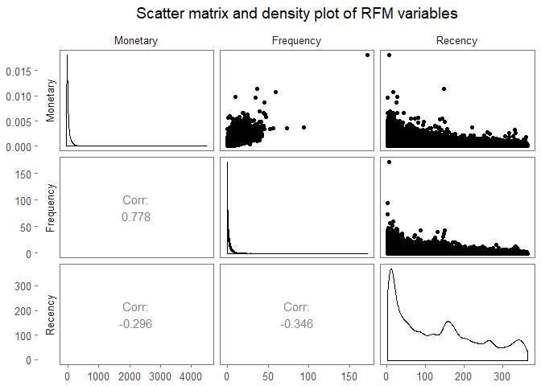

The scatter matrix shows the scatter plot for every combination of the RFM parameters and their density plot in the diagonal

```r
# I used the library name to determine the

GGally::ggpairs(RFMparameters[,2:4],
                title = "Scatter matrix and density plot of RFM variables",
                lower = list( continuous = 'cor' ),
                upper = list( continuous = "points" ),
                switch = 'y' ) +
  ggthemes::theme_few() +
  ggplot2::theme( plot.title = ggplot2::element_text(hjust = 0.5))
```

# 3 Assign a ranking number to customers for each RFM parameter

This task is demanding and there are many alternatives on how to segment the RFM parameters.

The method proposed:

- For each RFm parameter five clusters were calculated with K-means algorithm.
- K-means computed 5 clusters with different Means for each RFM parameter. I will not go into details about the inner works of K-means nor examine assumptions.
- For Frequency and Monetary, the cluster with the biggest mean was named ‘5’, the next one ‘4’ and so on. For Recency, the cluster was the smallest mean was named ‘5’ since we want recent customers to have biggest score.

```r
set.seed(123)
k = kmeans(RFMparameters$Frequency,5,nstart = 20) ## Frequency kmeans
M = kmeans(RFMparameters$Monetary,5,nstart = 20)  ## Monetary kmeans
R = kmeans(RFMparameters$Recency,5,nstart = 20)  ## Recency kmeans

Fr <- ifelse(k$cluster==1 , 2, ifelse(k$cluster==2,4,ifelse(k$cluster==3,3,ifelse(k$cluster==4,1,5))))
RFMparameters$Fr = Fr

Mon <- ifelse(M$cluster==1,3, ifelse(M$cluster==2,1,ifelse(M$cluster==3,4,ifelse(M$cluster==4,5,2))))
RFMparameters$M = Mon


Rec <- ifelse(R$cluster==1,5, ifelse(R$cluster==2,4,ifelse(R$cluster==3,3,ifelse(R$cluster==4,2,1))))
RFMparameters$R = Rec
```

## 3.1 How many Customers are in each cluster?

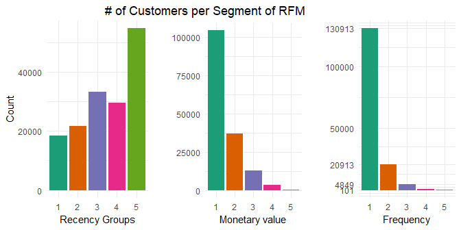

```r
g1 <- ggplot(RFMparameters,
             aes(factor(R))) +
  geom_bar(
    aes(y=(..count..)), #Count
    fill=c(brewer.pal(5,"Dark2")))+
  ggtitle("   ") +
  xlab("")+
  ylab("Count")+
  theme_minimal()+
  theme( plot.title = element_text(hjust = 0.5) ) +
  xlab('Recency Groups')

g2 <- ggplot(RFMparameters,
             aes(factor(M))) +
  geom_bar(
    aes(y=(..count..)), #Count
    fill=c(brewer.pal(5,"Dark2")))+
  xlab("")+
  ylab("")+
  theme_minimal()+
  ggtitle("# of Customers per Segment of RFM   ")+
  theme( plot.title = element_text(hjust = .88) ) +
  xlab('Monetary value')

g3 <- ggplot(RFMparameters,
             aes(factor(Fr))) + # Fr = Grouped Frequency
  geom_bar(
    aes(y=(..count..)), #Count
    fill=c(brewer.pal(5,"Dark2"))) +
  xlab("")+
  ylab("") +
  theme_minimal() +
  ggtitle("   ") +
  xlab('Frequency')+
  scale_y_continuous(limits = c(0,130913),
                     breaks = c(101,4849,20913,50000,100000,130913))
multiplot(g1, g2, g3, cols = 3)
```

## 3.2 Recent and Frequent Customers Spending Habbits

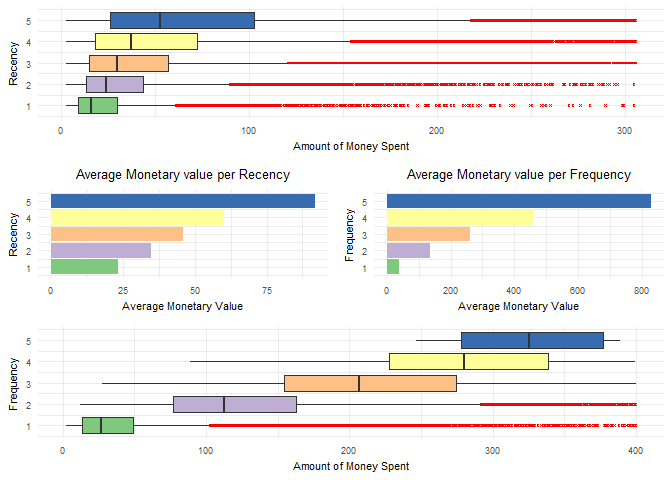

```r
g1 = RFMparameters %>%
  ggplot( aes(x = R,
              y = Monetary,
              fill = factor(R)) ) +
  geom_boxplot(outlier.shape = 4,
               outlier.colour = 'red',
               outlier.size = 0.2) +
  scale_y_continuous(limits = quantile(RFMparameters$Monetary,
                                       c(0.01, 0.98))) +
  scale_fill_brewer(palette = 'Accent') +
  theme_minimal() +
  coord_flip() +
  theme( text = element_text(size=8)) +
  xlab('Recency') +
  ylab('Amount of Money Spent') +
  guides(fill = F)


g2 =  RFMparameters %>%
  ggplot( aes(x = Fr,
              y = Monetary,
              fill = factor(Fr)) ) +
  geom_boxplot(outlier.shape = 4,
               outlier.colour = 'red',
               outlier.size = 0.2) +
  scale_fill_brewer(palette = 'Accent') +
  scale_y_continuous(limits = quantile(RFMparameters$Monetary,
                                       c(0.01, 0.99))) +
  theme_minimal() +
  coord_flip() +
  theme( plot.title = element_text(hjust = 0.5),
         text = element_text(size = 8)) +
  xlab('Frequency') +
  ylab('Amount of Money Spent') +
  guides(fill = F)


g3 <- RFMparameters %>%
  group_by(R) %>%
  summarise( Avg_Monetary = sum( Monetary ) / n()) %>%
  ggplot( aes(x = R,
              y = Avg_Monetary,
              fill = factor(R)) ) +
  geom_bar(stat = "identity") +
  scale_fill_brewer(palette = 'Accent')+
  theme_minimal() +
  coord_flip() +
  ggtitle("Average Monetary value per Recency") +
  theme( plot.title = element_text(hjust = 0.5),
         text = element_text(size=8)) +
  xlab('Recency') +
  ylab('Average Monetary Value') +
  guides(fill = F)


g4 <- RFMparameters %>%
  group_by(Fr) %>%
  summarise( Avg_Monetary = sum( Monetary ) / n()) %>%
  ggplot( aes(x = Fr,
              y = Avg_Monetary,
              fill = factor(Fr)) ) +
  geom_bar(stat = "identity") +
  scale_fill_brewer(palette = 'Accent')+
  theme_minimal() +
  coord_flip() +
  ggtitle("Average Monetary value per Frequency") +
  theme( plot.title = element_text(hjust = 0.5),
         text = element_text(size=8)) +
  xlab('Frequency') +
  ylab('Average Monetary Value') +
  guides(fill = F)

library(grid)

# Create layout : nrow = 3, ncol = 2
pushViewport(viewport(layout = grid.layout(nrow = 3, ncol = 2)))
# A helper function to define a region on the layout
define_region <- function(row, col){
  viewport(layout.pos.row = row, layout.pos.col = col)
}
# Arrange the plots
print(g1, vp = define_region(row = 1, col = 1:2))   # Span over two columns
print(g3, vp = define_region(row = 2, col = 1))
print(g4, vp = define_region(row = 2, col = 2))
print(g2 , vp = define_region(row = 3, col = 1:2))
```

## 3.3 Visualise K-means Clusters for each RFM parameter

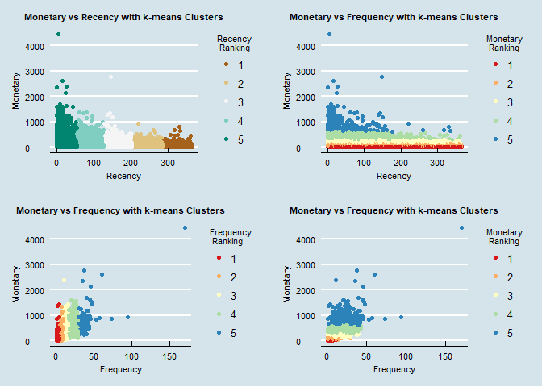

```r
g1 <- ggplot(RFMparameters,
             aes(x = Recency,
                 y = Monetary,
                 colour = factor(R)))+
  geom_point()+
  scale_color_brewer(name = 'Recency \n Ranking',
                     palette = 'BrBG' )+
  theme_economist()+
  ggtitle('Monetary vs Recency with k-means Clusters')+
  theme( plot.title = element_text(hjust = 0.5,
                                   size = 8),
         text = element_text(size = 8),
         legend.position = 'right')


g2 <- ggplot(RFMparameters,
             aes(x = Frequency,
                 y = Monetary,
                 colour = factor(Fr))) +
  geom_point() +
  scale_color_brewer(name = 'Frequency \n Ranking',
                     palette = 'Spectral' ) +
  theme_economist() +
  ggtitle('Monetary vs Frequency with k-means Clusters') +
  theme( plot.title = element_text(hjust = 0.5,
                                   size = 8),
         text = element_text(size=8),
         legend.position = 'right')

g3 <- ggplot(RFMparameters,
             aes(x = Recency,
                 y = Monetary,
                 colour = factor(M)))+
  geom_point()+
  scale_color_brewer(name = 'Monetary \n Ranking',
                     palette = 'Spectral' )+
  theme_economist() +
  ggtitle('Monetary vs Frequency with k-means Clusters') +
  theme( plot.title = element_text(hjust = 0.5,
                                   size = 8),
         text = element_text(size=8),
         legend.position = 'right')

g4 <- ggplot(RFMparameters,
             aes(x = Frequency,
                 y = Monetary,
                 colour = factor(M)))+
  geom_point()+
  scale_color_brewer(name = 'Monetary \n Ranking',
                     palette = 'Spectral' )+
  theme_economist() +
  ggtitle('Monetary vs Frequency with k-means Clusters') +
  theme( plot.title = element_text(hjust = 0.5,
                                   size = 8),
         text = element_text(size=8),
         legend.position = 'right')

multiplot(g1,g2,g3,g4,cols = 2)
```

# 4 Customer Segmentation based on RFMscore

```r
# RFM score calculation
RFMparameters <-  RFMparameters %>%
  mutate(RFMcell = paste0(R, Fr, M))  %>%
  mutate(RFMscore = .2*R + .3*Fr + .5*M) %>%
  mutate(Customer_Segment = .bincode( RFMscore,
                                      breaks = quantile(
                                        RFMscore,
                                        c(0,.08,.22,.52,.77,0.92,1)
                                        ),
                                      include.lowest = TRUE)) %>%
  mutate(Customer_Segment = factor(Customer_Segment,
                                   labels = c("WHITE",
                                              "YELLOW",
                                              "BRONZE",
                                              "SILVER",
                                              "GOLD",
                                              "STAR")))
```

## 4.1 From STAR to WHITE: # of Customers per Segment

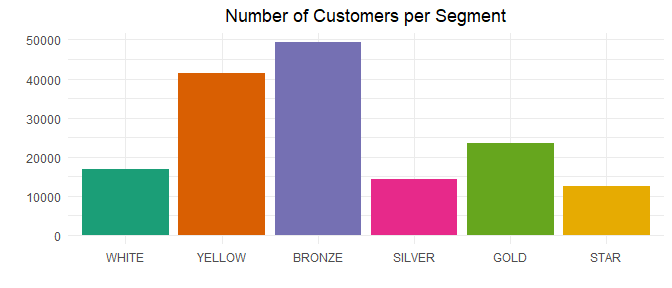

```r
RFMparameters %>%
  ggplot(aes(factor(Customer_Segment))) +
  geom_bar(
    aes(y=(..count..)), #Count
    fill=c(brewer.pal(6,"Dark2"))) +
  xlab("")+
  ylab("") +
  theme_minimal()+
  ggtitle('Number of Customers per Segment')+
  theme(plot.title = element_text(hjust = 0.5) )
```